# HeartRateLab — Resonant_Breathing — Resonance Breathing Report

#### Resonant Frequency Breathing — HRV Training Report

Personal HRV training analysis for **Resonant_Breathing**. All comparisons use **360-beat windows / 120-beat stride**. Normative reference: *nsr2db + nsrdb* (56472 windows pooled).

148  
total windows

88  
recording dates

56472  
normative windows

**All Normal reference**

**Combined Healthy-Population Reference** nsr2db + nsrdb

56472  
total 360-beat windows

2  
datasets pooled

This combined group is the normative reference used for participant distribution scoring. Fitted prior distributions (from `normative_priors.csv`) define the quantile-based dispersion bands, respecting each feature's distribution family.

##### Between-Dataset Distributions (healthy populations)

Each coloured curve represents one healthy-population dataset. Divergence indicates dataset-specific distributional differences.

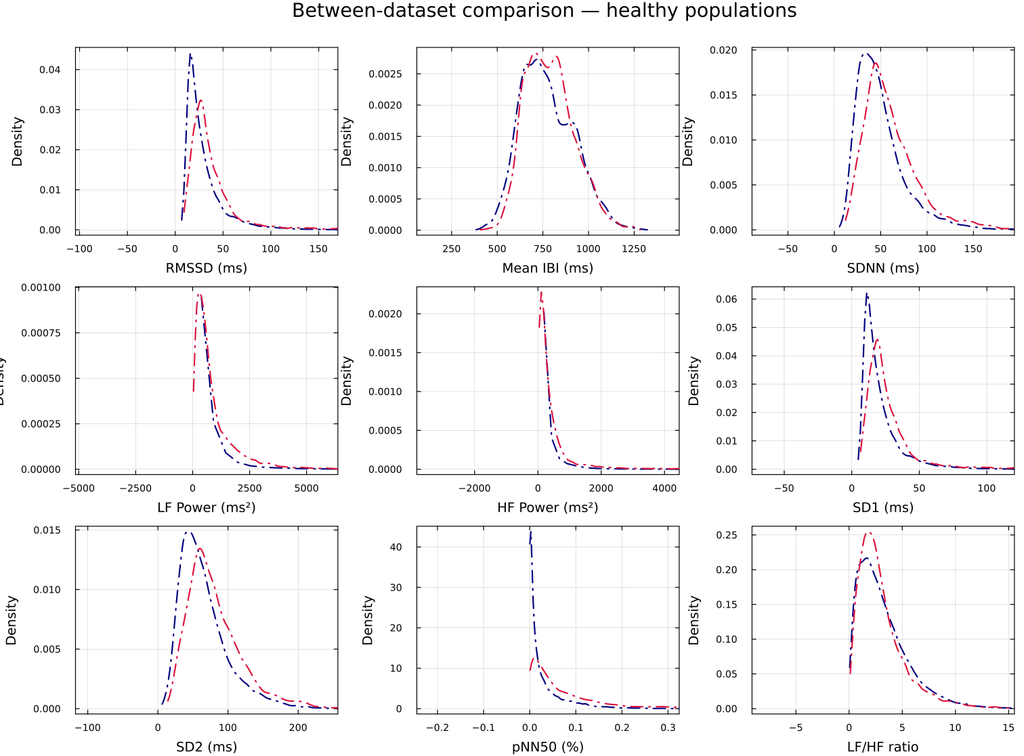

##### Combined-Normal Correlation Matrix

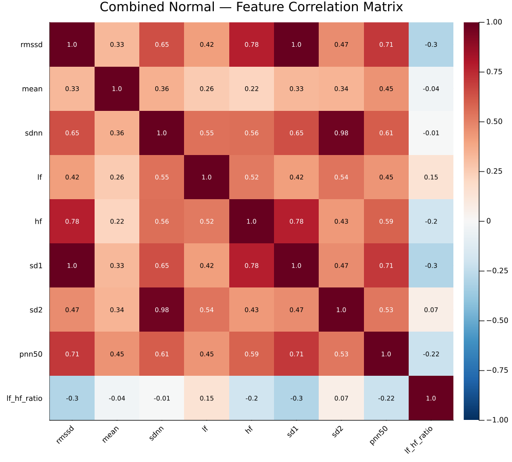

##### Healthy-Population Pairplot

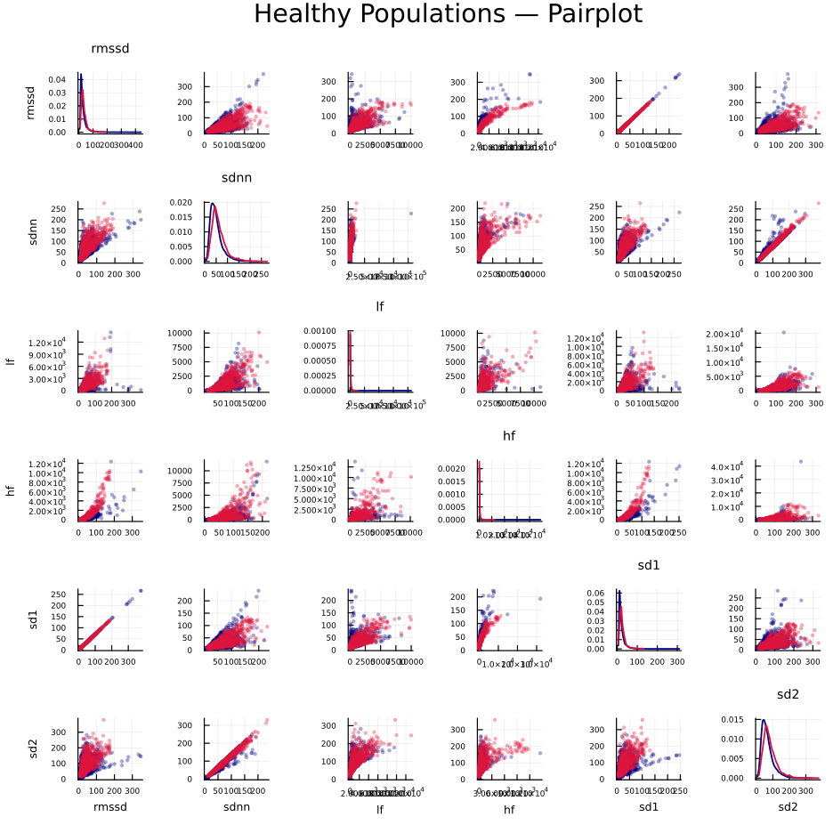

**One-way ANOVA across Normative Datasets**

Participant-level one-way ANOVA across **2 normative datasets** (nsr2db (n=48), nsrdb (n=18); **66 participants total**).

| Feature | F | p-value | N participants | Result | Interpretation |
| --- | --- | --- | --- | --- | --- |
| RMSSD (ms) | `1.989` | `0.16333` | 66 | not sig. | Not significant |
| Mean IBI (ms) | `0.366` | `0.54758` | 66 | not sig. | Not significant |
| SDNN (ms) | `9.694` | `0.00276` | 66 | significant | Significant (p < 0.05) |
| LF Power (ms²) | `14.379` | `0.00033` | 66 | significant | Highly significant (p < 0.001) |
| HF Power (ms²) | `7.177` | `0.00937` | 66 | significant | Significant (p < 0.05) |
| SD1 (ms) | `1.989` | `0.16334` | 66 | not sig. | Not significant |
| SD2 (ms) | `12.202` | `0.00087` | 66 | significant | Highly significant (p < 0.001) |
| pNN50 (%) | `18.046` | `0.00007` | 66 | significant | Highly significant (p < 0.001) |
| LF/HF ratio | `0.054` | `0.81758` | 66 | not sig. | Not significant |

**Summary:** **5 / 9 features** show significant differences.

**Training HRV Resonant_Breathing**

**Resonant_Breathing** resonant breathing training

148  
360-beat windows

88  
recording dates

9  
features extracted

Normative reference: **nsr2db + nsrdb** (56472 windows). Distribution bands derived from fitted priors (Normal/Gamma/Beta/LogNormal per feature).

##### Feature Distributions vs Normative Reference

KDE curves for each HRV feature. Dispersion bands (central 68% / 95% / 99.7%) derived from fitted normative prior distributions (nsr2db + nsrdb).

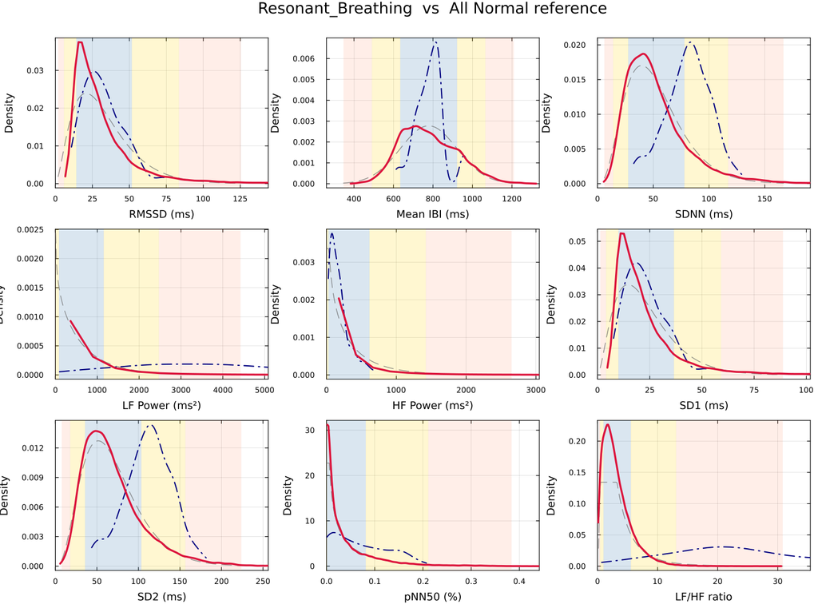

##### Distributional Deviation Analysis

Distributional deviation — *Resonant_Breathing* median window vs fitted normative prior (360-beat windows) — 88 recording dates, 148 windows

| Feature | Family | Location | Dispersion | Participant median | Percentile | Z-equiv | N (windows) | Interpretation |
| --- | --- | --- | --- | --- | --- | --- | --- | --- |
| RMSSD (ms) | Gamma | 32.87 | 25.14 (IQR) | 29.38 | 51.0% | +0.025 | 148 | Within central 68% — typical |
| Mean IBI (ms) | Normal | 778.07 | 143.71 (σ) | 788.08 | 52.8% | +0.070 | 148 | Within central 68% — typical |
| SDNN (ms) | Gamma | 52.72 | 33.85 (IQR) | 82.17 | 86.9% | +1.121 | 148 | Within central 95% — slightly atypical |
| LF Power (ms²) | Gamma | 614.81 | 699.63 (IQR) | 3461.49 | 99.5% | +2.549 | 148 | Within central 99.7% — notably atypical |
| HF Power (ms²) | Gamma | 318.72 | 379.42 (IQR) | 142.64 | 43.4% | -0.167 | 148 | Within central 68% — typical |
| SD1 (ms) | Gamma | 23.28 | 17.8 (IQR) | 20.8 | 51.0% | +0.025 | 148 | Within central 68% — typical |
| SD2 (ms) | Gamma | 69.54 | 45.45 (IQR) | 112.39 | 88.3% | +1.189 | 148 | Within central 95% — slightly atypical |
| pNN50 (%) | Beta | 0.04 | 0.05 (IQR) | 0.06 | 77.1% | +0.742 | 148 | Within central 68% — typical |
| LF/HF ratio | LogNormal | 2.36 | 2.88 (IQR) | 22.62 | 99.6% | +2.639 | 148 | Within central 99.7% — notably atypical |

##### Feature Correlation Matrix

Pearson correlations across all 148 windows.

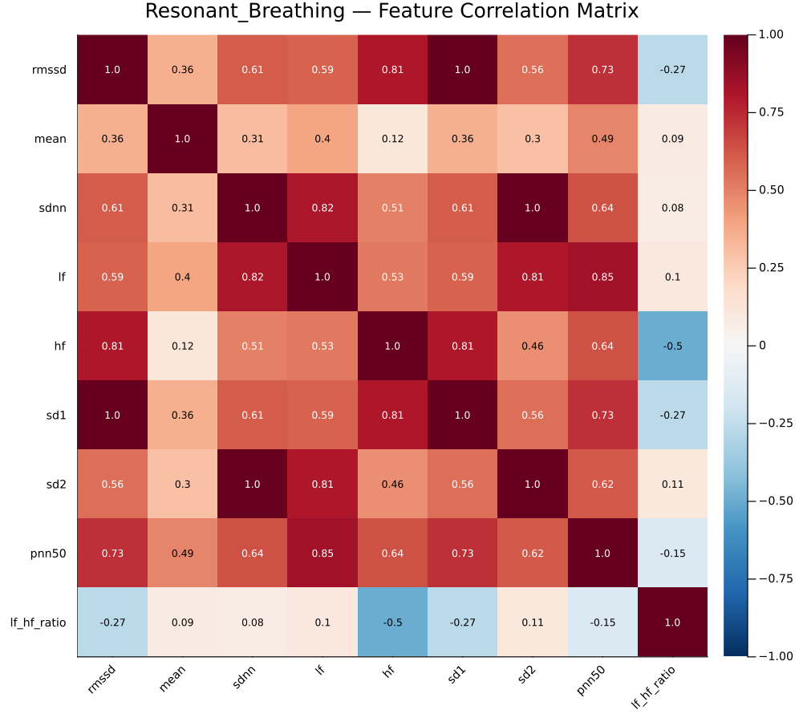

##### Feature Pairplot

Scatter matrix of core features. All Normal reference overlaid.

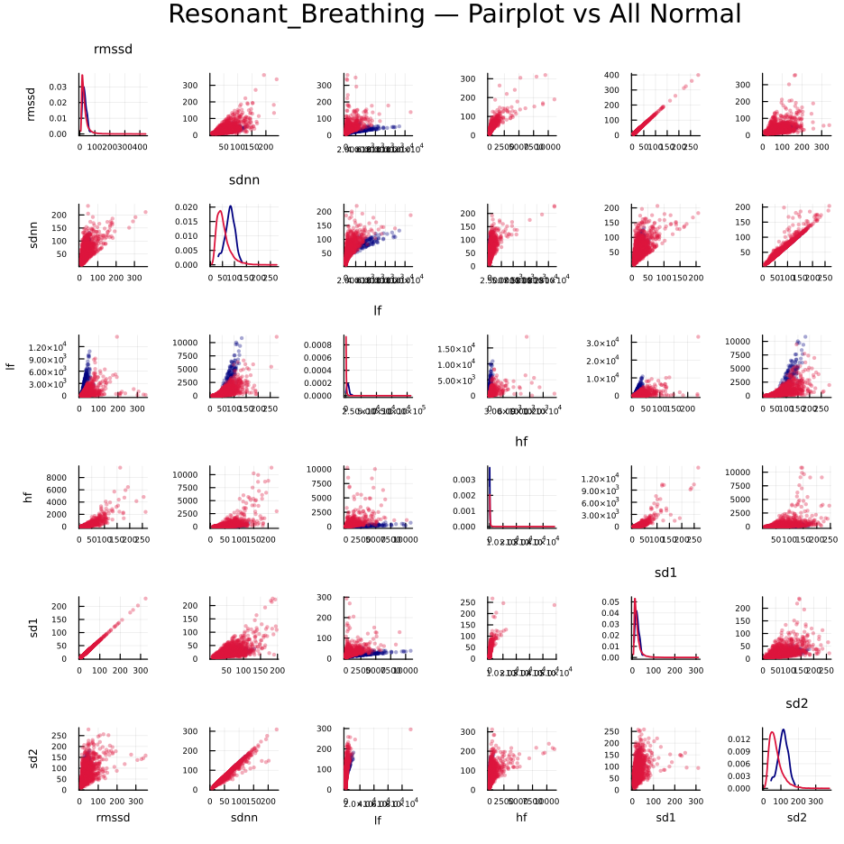

**Timeline 88 dates**

**HRV Feature Timeline — Resonant_Breathing**

2019-09-11  
first recording

2025-04-16  
last recording

88  
recording dates

0  
dates with 95% CI

20  
min windows for CI

Each point represents the **mean feature value** across all 360-beat windows from that recording date. **95% bootstrap confidence intervals** (1000 resamples, α = 0.05) are shown for dates with ≥ 20 windows. Shaded bands show the normative ±1σ (blue) and ±2σ (gold) reference range; dashed line = normative median/mean.

Select feature to display:

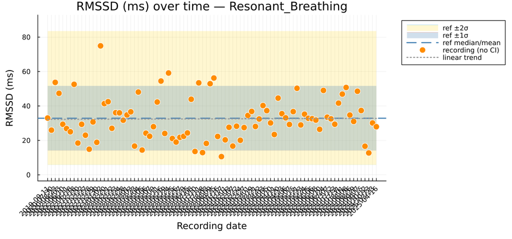

**Recording details — 88 dates (click to expand)**

| Date | Windows | Bootstrap CI eligible |
| --- | --- | --- |
| 2019-09-11 | 1 | no — 1 window |
| 2020-07-30 | 3 | no — 3 windows |
| 2020-08-23 | 1 | no — 1 window |
| 2022-06-03 | 1 | no — 1 window |
| 2022-06-10 | 1 | no — 1 window |
| 2022-06-11 | 1 | no — 1 window |
| 2022-06-18 | 1 | no — 1 window |
| 2022-12-18 (8 sessions) | 8 | no — 8 windows |
| 2022-12-20 | 1 | no — 1 window |
| 2022-12-22 (7 sessions) | 7 | no — 7 windows |
| 2022-12-27 (6 sessions) | 7 | no — 7 windows |
| 2022-12-28 (3 sessions) | 3 | no — 3 windows |
| 2022-12-29 (2 sessions) | 2 | no — 2 windows |
| 2022-12-30 | 1 | no — 1 window |
| 2023-01-02 | 1 | no — 1 window |
| 2023-02-20 | 1 | no — 1 window |
| 2023-02-21 (3 sessions) | 3 | no — 3 windows |
| 2023-02-22 (5 sessions) | 5 | no — 5 windows |
| 2023-02-23 | 1 | no — 1 window |
| 2023-02-24 | 1 | no — 1 window |
| 2023-02-28 (2 sessions) | 2 | no — 2 windows |
| 2023-03-01 | 1 | no — 1 window |
| 2023-03-03 | 1 | no — 1 window |
| 2023-03-23 | 2 | no — 2 windows |
| 2023-05-04 (2 sessions) | 2 | no — 2 windows |
| 2023-05-05 (2 sessions) | 2 | no — 2 windows |
| 2023-05-06 | 1 | no — 1 window |
| 2023-05-07 | 1 | no — 1 window |
| 2023-05-09 | 1 | no — 1 window |
| 2023-05-11 (2 sessions) | 2 | no — 2 windows |

[output cut: 58 more lines]